# Prediciting Flight Delays

Divya Virmani, Nebadita Nayak, Navneeth Baliga, Shyam Mohan

December 15th, 2017

```r
#Required Libraries


library(leaps)          # variable selection
library(ggplot2)        # graphics library
library(ISLR)           # contains code and data from the textbook
library(knitr)          # contains knitting control
library(tree)           # For the tree-fitting 'tree' function
library(MASS)           # For Boston data
library(randomForest)   # For random forests and bagging
library(gbm)            # For boosting
library(glmnet)
library(caret)
library(tree)
library(boot)
library("pROC")         # For RoC Curve
cbPalette <- c("#999999", "#E69F00", "#56B4E9", "#009E73", "#F0E442", "#0072B2", "#D55E00", "#CC79A7")
options(scipen = 4)  # Suppresses scientific notation

#Reading the flight data.
flight <- read.csv("http://www.andrew.cmu.edu/user/achoulde/95791/projects/Project%20D/all_PIT_2006.csv")
#flight2016<- read.csv("/Users/nav/Desktop/all_PIT_2016.csv")
id <- "1hEo-zXqgrC7HBwre73q3rHgeViKGvcjQ"
flight2016 <- read.csv(sprintf("https://docs.google.com/uc?id=%s&export=download", id))
flight2016[is.na(flight2016)] <- 0

#Keeping a copy of the flight data for sampling purposes.
rflight <- flight
rflight2016 <- flight2016


#Re formatting the data
#Ref : https://stackoverflow.com/questions/26334763/merge-three-different-columns-into-a-date-in-r
flight$FlightDate = as.Date(with(flight, paste(flight$Year,flight$Month, flight$DayofMonth, sep ="-")),"%Y-%m-%d")
flight2016$FlightDate = as.Date(with(flight2016, paste(flight2016$Year,flight2016$Month, flight2016$DayofMonth, sep ="-")),"%Y-%m-%d")
```

## Cancelled and Diverted flight records are removed since they do not contribute towards the project goal.

```r
#Remve the records from the data where the flight is Cancelled as those columns do not have response varibale value of flight delay.This step handles the null variable case.

#Remove null records from 2016 data
#flight2016 = na.omit(flight2016)

#Remove details of cancelled and diverted flights.
flight = subset(flight, (flight$Cancelled==0 & flight$Diverted==0))
flight2016 = subset(flight2016, (flight2016$Cancelled==0 & flight2016$Diverted==0))


#Let's see the null values in the next data set
colnames(flight)[colSums(is.na(flight)) > 0]
```

```
## character(0)
```

```r
colnames(flight2016)[colSums(is.na(flight2016)) > 0]
```

```
## character(0)
```

```r
#Percent of data still available after removing null records
nrow(flight)/nrow(rflight)
```

```
## [1] 0.9811889
```

```r
nrow(flight2016)/nrow(rflight2016)
```

```
## [1] 0.9980245
```

## Plot 1: Plot shows how Delay in Departure is varying with Carrier.

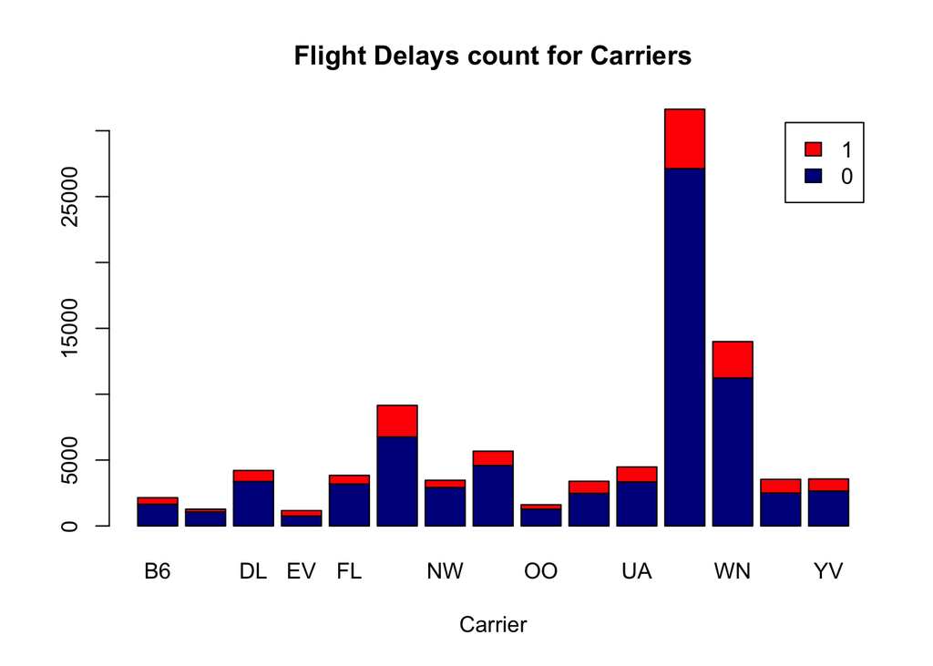

```r
count1 <- table(flight$DepDel15, flight$Carrier)
barplot(count1, main="Flight Delays count for Carriers",
  xlab="Carrier", col=c("darkblue","red"),
    legend = rownames(count1))
```

## From the data visualization above, we found that flight delays are varying with different carriers. Especially cariers like US experience a lot of delays as well as they exhibhit a high volume.

## Plot 2: Plot shows how Depdelay is varying in different Quarters.

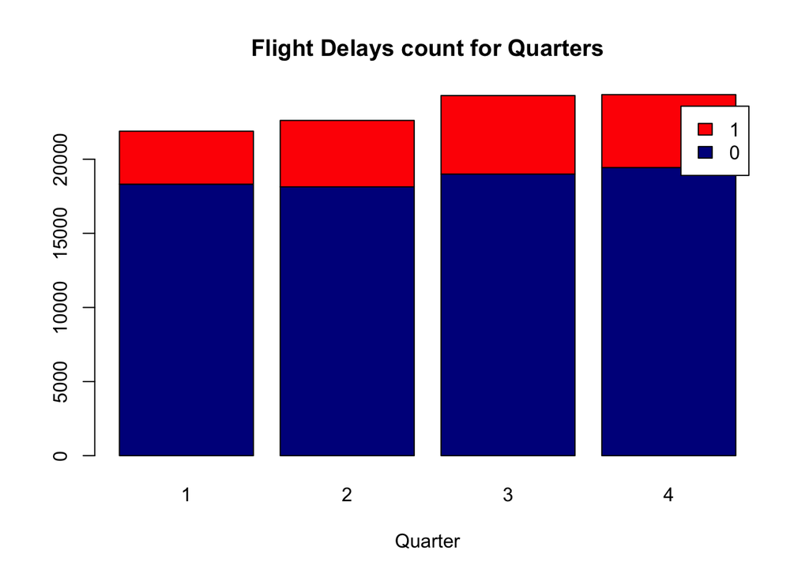

```r
count2 <- table(flight$DepDel15, flight$Quarter)
barplot(count2, main="Flight Delays count for Quarters",
  xlab="Quarter", col=c("darkblue","red"),
    legend = rownames(count2))
```

## From the data visualization above, we found that flight delays are varying with different quaters. For example, Quater 3 has maximum delays.

## Plot 3: Plot shows how Depdelay is varying in different month.

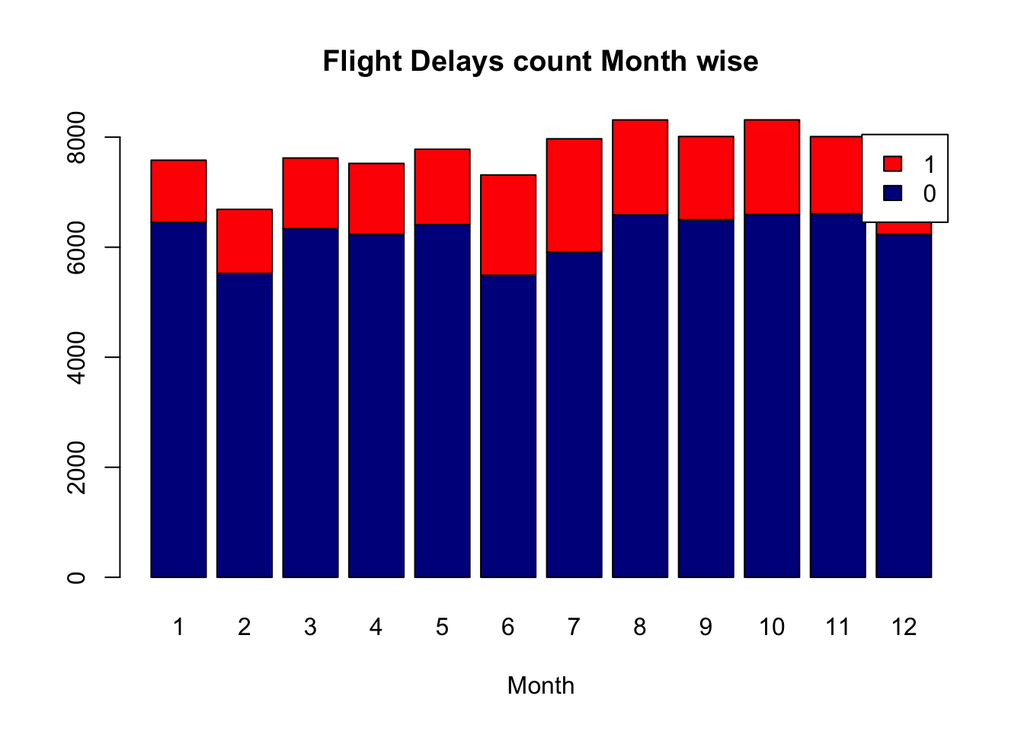

```r
count3 <- table(flight$DepDel15, flight$Month)
barplot(count3, main="Flight Delays count Month wise",
  xlab="Month", col=c("darkblue","red"),
    legend = rownames(count3))
```

## From the data visualization above, we found that flight delays are varying month wise. For example, month 7 has the maximum number of flight delays..

## Plot 4: Plot shows how Depdelay is varying on different day of the week.

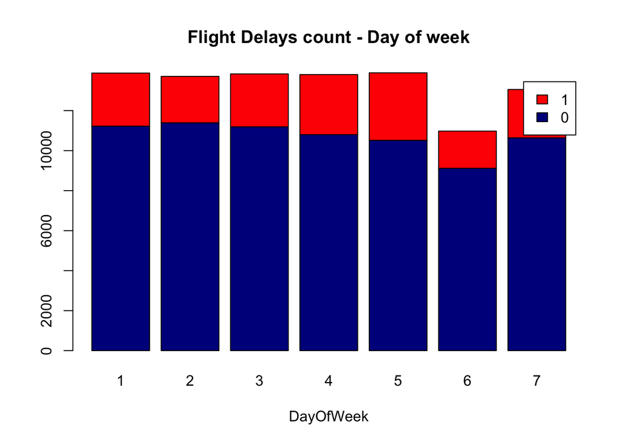

```r
count4 <- table(flight$DepDel15, flight$DayOfWeek)
barplot(count4, main="Flight Delays count - Day of week",
  xlab="DayOfWeek", col=c("darkblue","red"),
    legend = rownames(count4))
```

## From the data visualization above, we found that flight delays is different on different day of the week. For example, there are lot on delays durng mid week and during the weekend.

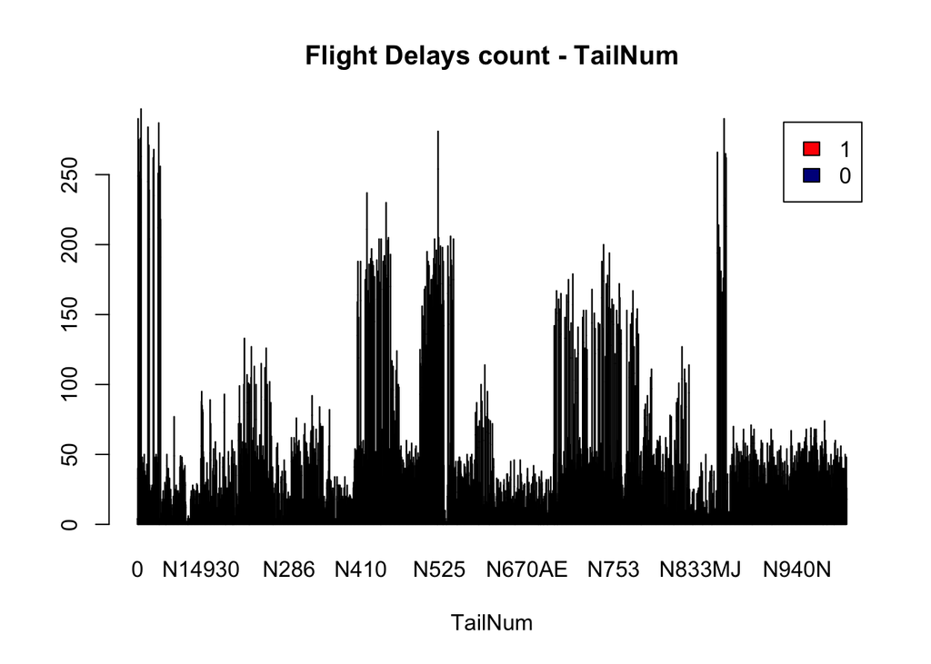

```r
count5 <- table(flight$DepDel15, flight$TailNum)
barplot(count5, main="Flight Delays count - TailNum",
  xlab="TailNum", col=c("darkblue","red"),
    legend = rownames(count5))
```

## From the data visualization above, we found that flight delays varying with tail number.

## Plot 6: Plot shows how Depdelay is varying with day of month.

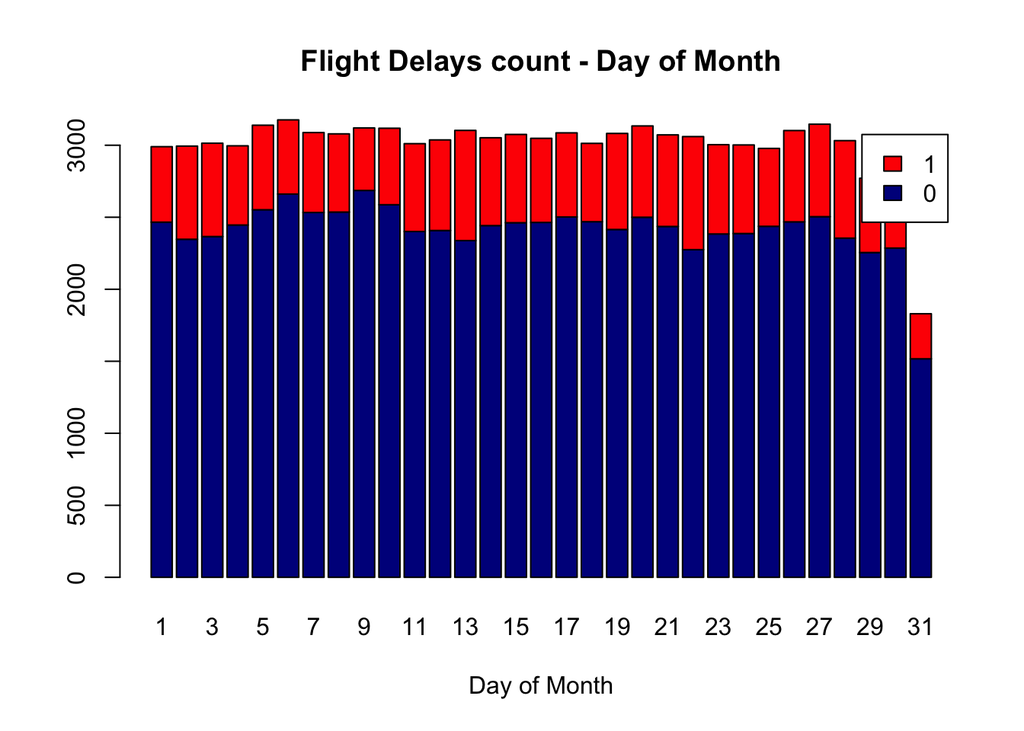

```r
count6 <- table(flight$DepDel15, flight$DayofMonth)
barplot(count6, main="Flight Delays count - Day of Month",
  xlab="Day of Month", col=c("darkblue","red"),
    legend = rownames(count6))
```

## From the data visualization above, we found that flight delays varies with different day of month. But it looks like there is not much variations.

## Plot 7: Plot shows how Depdelay is varying with flight date.

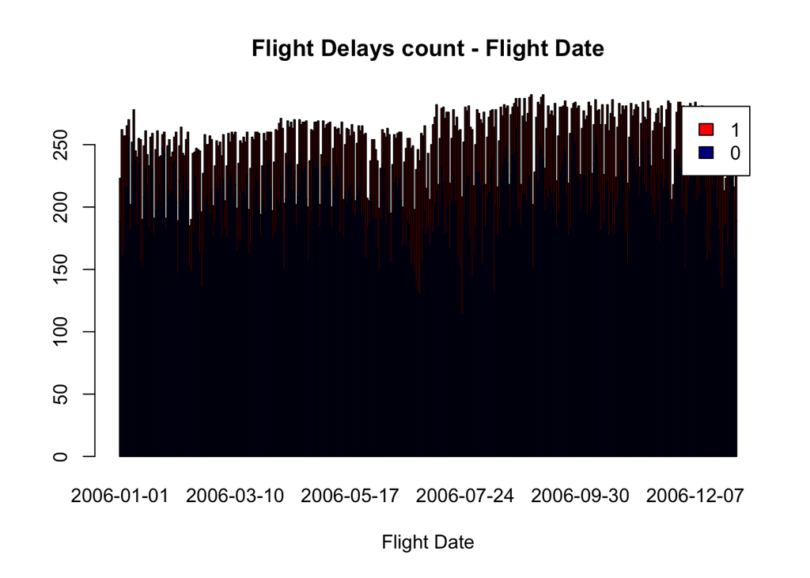

```r
count7 <- table(flight$DepDel15, flight$FlightDate)
barplot(count7, main="Flight Delays count - Flight Date",
  xlab="Flight Date", col=c("darkblue","red"),
    legend = rownames(count7))
```

## From the data visualization above, we found that flight delays are varying with flight date. There are huge variations in flight delays based on different dates.

## Plot 8: Plot shows how Depdelay is varying with distance.

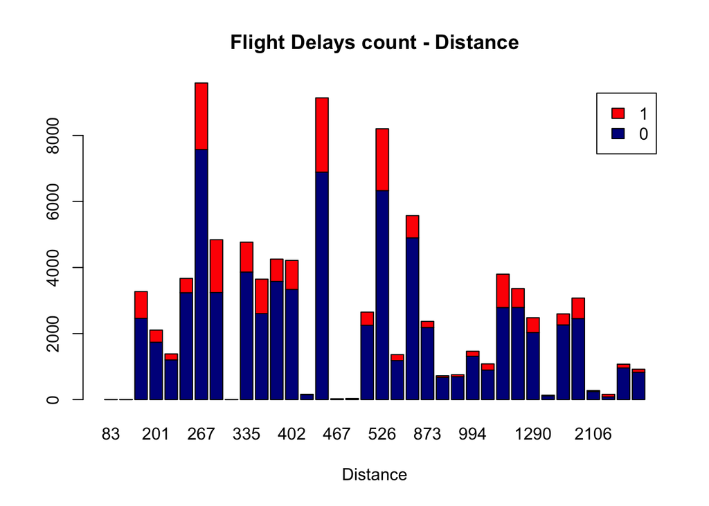

```r
count8 <- table(flight$DepDel15, flight$Distance)
barplot(count8, main="Flight Delays count - Distance",
  xlab="Distance", col=c("darkblue","red"),
    legend = rownames(count8))
```

## From the data visualization above, we found that flight delays are varying with distance. Different distances have different delays, since there are less long distance flights, there are lesser delays whereas there are more short distance flights, hence there are more delays.

## Plot 9: Plot shows how Depdelay is varying with CRS elapsed time.

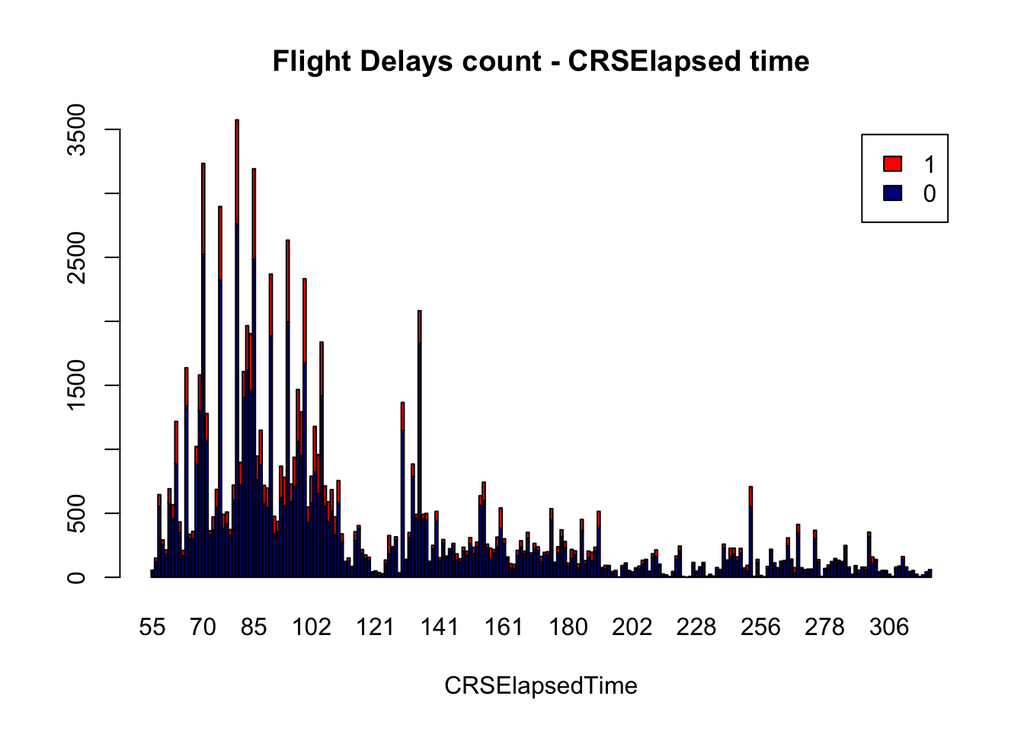

```r
count9 <- table(flight$DepDel15, flight$CRSElapsedTime)
barplot(count9, main="Flight Delays count - CRSElapsed time",
  xlab="CRSElapsedTime", col=c("darkblue","red"),
    legend = rownames(count9))
```

## From the data visualization above, we found that flight delays varying with different CRS Elapsed time. Smaller CRS elasped time has more delays compared to larger CRS elapsed time.

## Plot 10: Plot shows how Depdelay is varying with distance group.

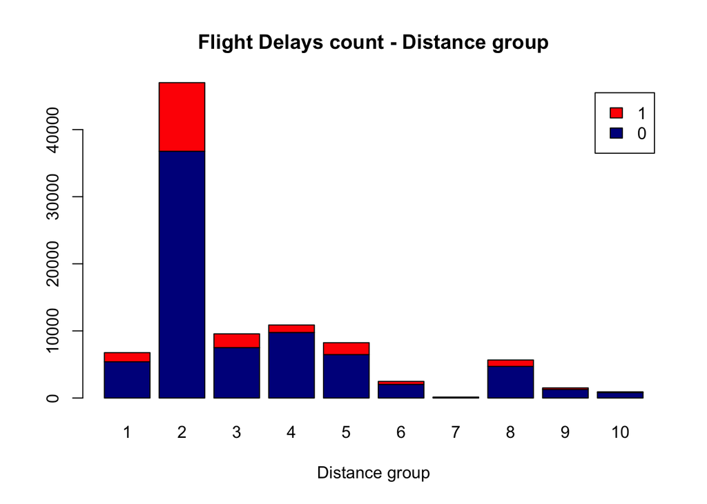

```r
count10 <- table(flight$DepDel15, flight$DistanceGroup)
barplot(count10, main="Flight Delays count - Distance group",
  xlab="Distance group", col=c("darkblue","red"),
    legend = rownames(count10))
```

## From the data visualization above, we found that flight delays are varying with different distance group For example, Distance group 2 has more number of delays.

## Plot 11: Plot shows how Depdelay is varying with Arrival time in bulk.

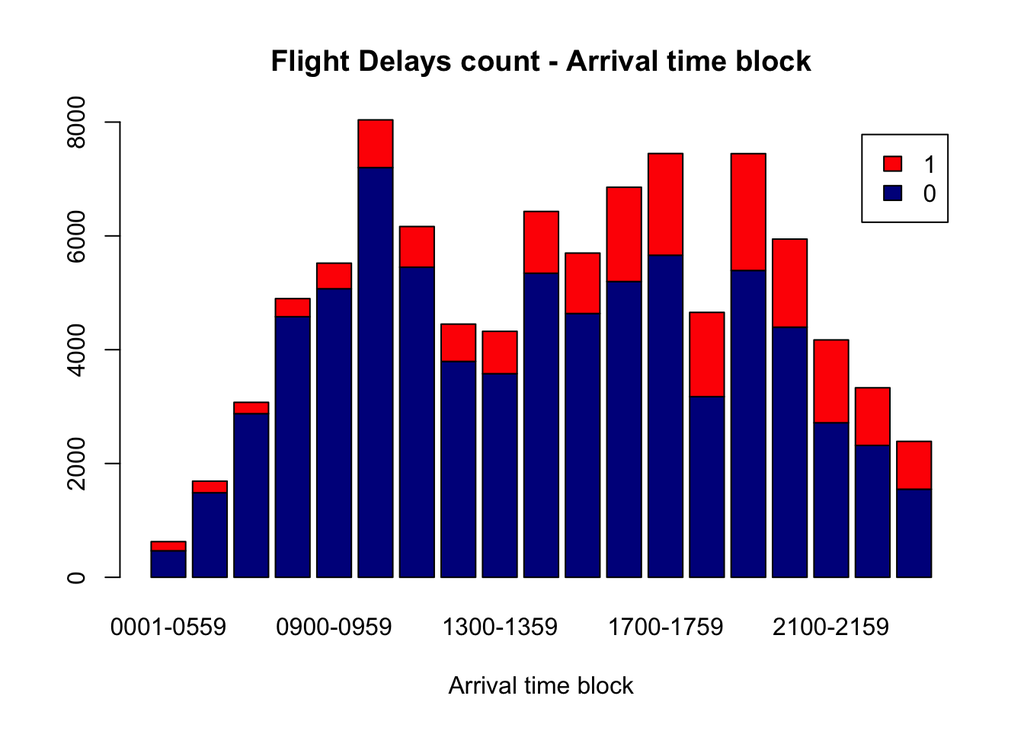

```r
count11 <- table(flight$DepDel15, flight$ArrTimeBlk)
barplot(count11, main="Flight Delays count - Arrival time block",
  xlab="Arrival time block", col=c("darkblue","red"),
    legend = rownames(count11))
```

## From the data visualization above, we found that flight delays are varying with different arrival time blocks.

## Plot 12: Plot shows how Depdelay is varying with Departure time in bulk.

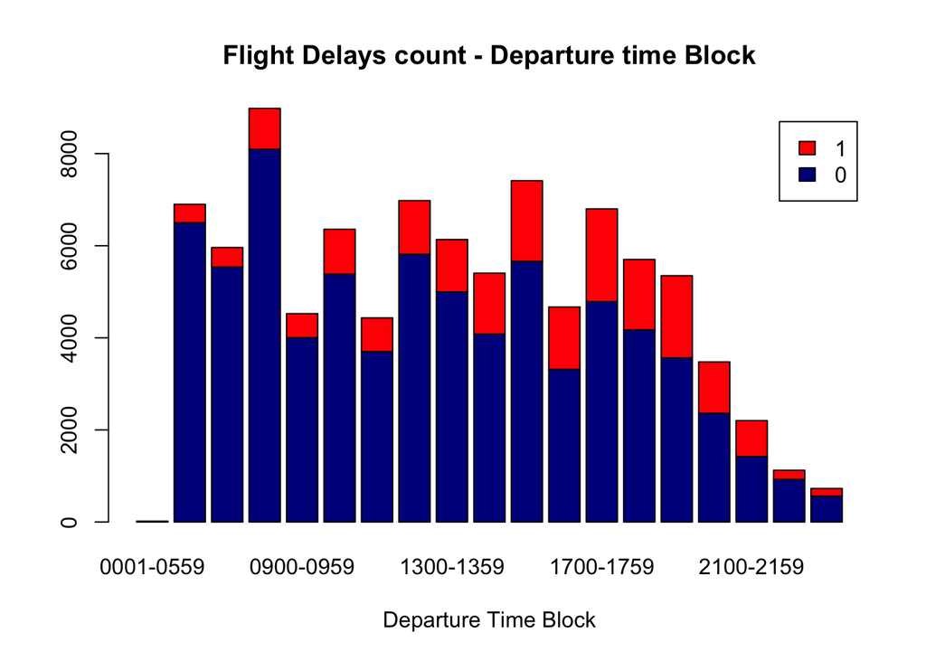

```r
count12 <- table(flight$DepDel15, flight$DepTimeBlk)
barplot(count12, main="Flight Delays count - Departure time Block",
  xlab="Departure Time Block", col=c("darkblue","red"),
    legend = rownames(count12))
```

## Plot 13: Plot shows how Depdelay is varying with Destination.

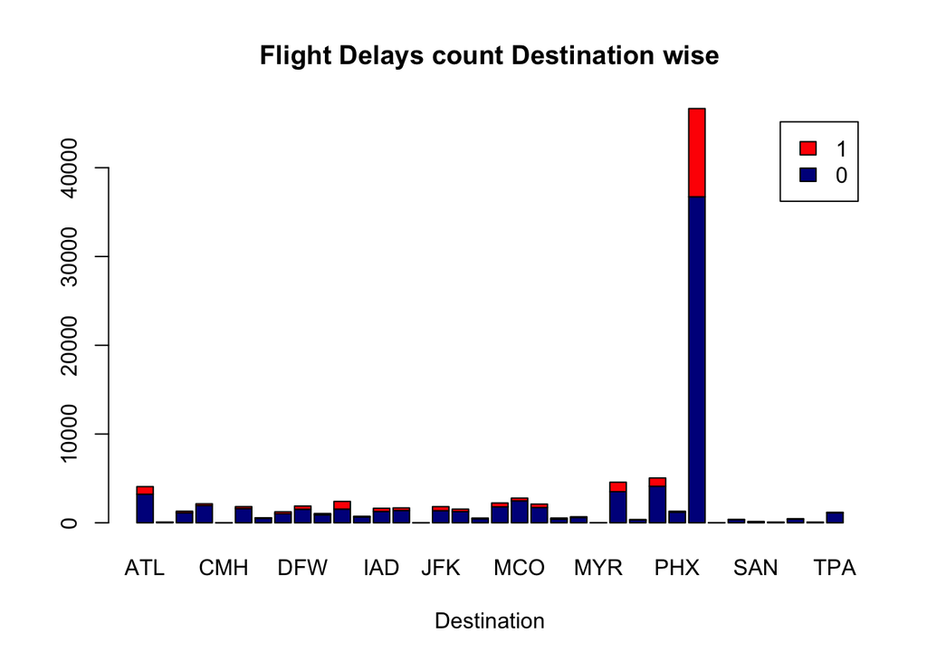

```r
count13 <- table(flight$DepDel15, flight$Dest)
barplot(count13, main="Flight Delays count Destination wise",
  xlab="Destination", col=c("darkblue","red"),
    legend = rownames(count13))
```

## From the data visualization above, we found that flight delays are varying with different destination.

```r
#Now, we would take variables that are not redundant, like Year, month, day of the month, day of week, depblck, arrival block are of no importance. SOw e would drop these variables


selectedCols = c("FlightDate", "Carrier",  "DayOfWeek", "Distance","ArrDelay",
                 "DistanceGroup", "CRSElapsedTime", "ArrTimeBlk", "DepTimeBlk", "Dest", "DepDel15")

flight = flight[selectedCols]
flight2016 = flight2016[selectedCols]

flight$DepDel15 = as.factor(flight$DepDel15)

#Make sure that the new 2016 categorical predictors have same levels of factors.
flight2016$Carrier <- factor(flight2016$Carrier, levels = levels(flight$Carrier))


flight2016$Dest <- factor(flight2016$Dest, levels = levels(flight$Dest))

flight2016$Distance = as.numeric(flight2016$Distance)
flight$DayOfWeek = as.factor(flight$DayOfWeek)
flight$DistanceGroup = as.factor(flight$DayOfWeek)
flight2016$CRSElapsedTime = as.numeric(flight2016$CRSElapsedTime)
flight2016$ArrDelay = as.numeric(flight2016$ArrDelay)
flight$ArrDelay = as.numeric(flight$ArrDelay)

#Make sure that the new 2017 categorical predictors have same levels of factors.
#Make sure that the new 2017 categorical predictors have same levels of factors.

flight2016$Carrier <- factor(flight2016$Carrier, levels = levels(flight$Carrier))
flight2016$Dest <- factor(flight2016$Dest, levels = levels(flight$Dest))
flight2016$DistanceGroup <- factor(flight2016$DistanceGroup, levels = levels(flight$DistanceGroup))
flight2016$DayOfWeek <- factor(flight2016$DayOfWeek, levels = levels(flight$DayOfWeek))
flight2016$ArrTimeBlk <- factor(flight2016$ArrTimeBlk, levels = levels(flight$ArrTimeBlk))
flight2016$DepTimeBlk <- factor(flight2016$DepTimeBlk, levels = levels(flight$DepTimeBlk))


flight2016 = na.omit(flight2016)
```

```r
#We will Run logistic regression on the data


#Creating Dummy Variables
flights.dummy = model.matrix(~Carrier +Dest + DistanceGroup , data = flight)
flights.dummy <- flights.dummy[,-1]
flights.dummy = data.frame(flights.dummy)

flights.dummy = merge(flights.dummy,flight, by = 0)
flights.dummy$Row.names = NULL
flights.dummy$Carrier = NULL
flights.dummy$Origin =NULL
flights.dummy$Dest = NULL
flights.dummy$DistanceGroup = NULL

#Creating Dummy Variables in the 2016 data.
flights.dummy2016 = model.matrix(~Carrier +Dest + DistanceGroup  , data = flight2016)
flights.dummy2016 <- flights.dummy2016[,-1]
flights.dummy2016 = data.frame(flights.dummy2016)

flights.dummy2016 = merge(flights.dummy2016,flight2016, by = 0)
flights.dummy2016$Row.names = NULL
flights.dummy2016$Carrier = NULL
flights.dummy2016$Origin =NULL
flights.dummy2016$DistanceGroup = NULL
flights.dummy2016$Dest = NULL

#Split data into two parts for Logistic Regression. For Logistic Regression model, we need to
set.seed(1)
n <- nrow(flight)
shuffled_df <- flights.dummy[sample(n), ]
train_indices <- 1:round(0.6 * n)
train <- shuffled_df[train_indices, ]
test_indices <- (round(0.6 * n) + 1):n
test <- shuffled_df[test_indices, ]
```

```r
#Logistic regression on 2006 Data
flight.lr = glm(DepDel15 ~ . , data = train, family = "binomial")
# Discerning the results of the logistic regression.
predict.lr = predict.glm(flight.lr , newdata  = test, type = "response")
result.lr = rep(0, nrow(test))
result.lr[predict.lr>= 0.5] = 1
table(result.lr, test$DepDel15)
```

```
##
## result.lr     0     1
##         0 29134  2342
##         1   842  4945
```

```r
mean(result.lr == test$DepDel15)
```

```
## [1] 0.9145533
```

```r
#Predicting on 2016 Data

#na.omit(flights.dummy2016)
flight.lr = glm(DepDel15 ~ . , data = flights.dummy, family = binomial)
predict.lr = predict(flight.lr , newdata  = flights.dummy2016, type = "response")
result.lr = rep(0, nrow(flights.dummy2016))
result.lr[predict.lr>= 0.5] = 1
confusionMatrix(result.lr, flights.dummy2016$DepDel15, positive = "1")
```

```
## Confusion Matrix and Statistics
##
##           Reference
## Prediction     0     1
##          0 26921  2013
##          1   266  2924
##
##                Accuracy : 0.9291
##                  95% CI : (0.9262, 0.9318)
##     No Information Rate : 0.8463
##     P-Value [Acc > NIR] : < 2.2e-16
##
##                   Kappa : 0.6811
##  Mcnemar's Test P-Value : < 2.2e-16
##
##             Sensitivity : 0.59226
##             Specificity : 0.99022
##          Pos Pred Value : 0.91661
##          Neg Pred Value : 0.93043
##              Prevalence : 0.15369
##          Detection Rate : 0.09102
##    Detection Prevalence : 0.09930
##       Balanced Accuracy : 0.79124
##
##        'Positive' Class : 1
##
```

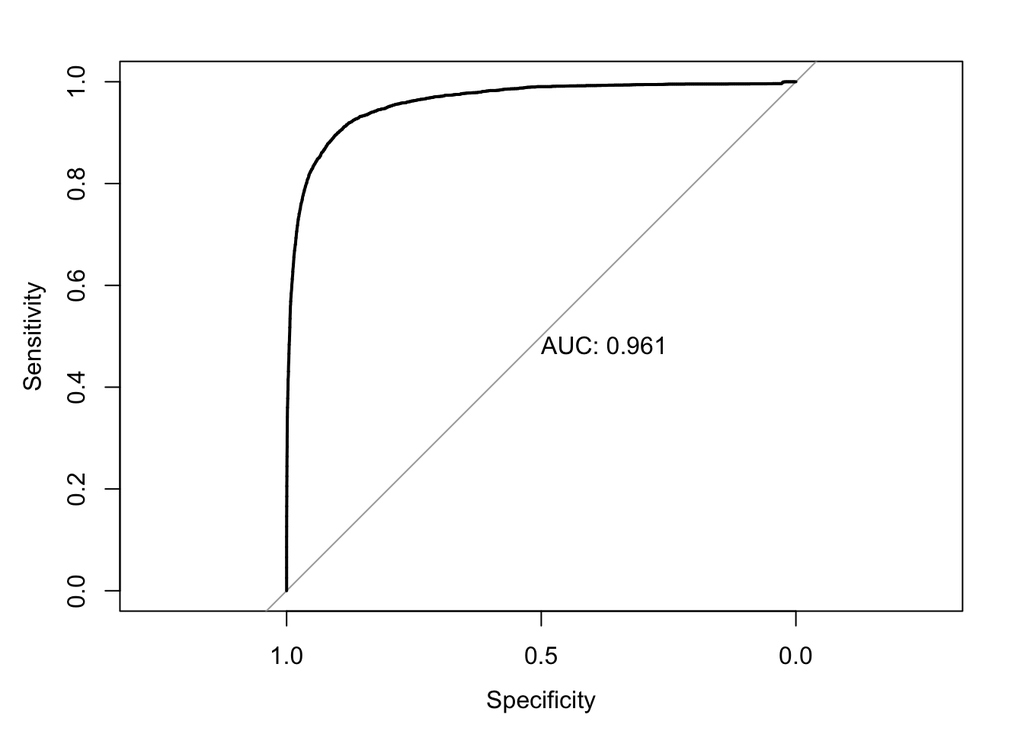

```r
#ROC Curve for Logistic regression

prob.lr = data.frame(predict.lr)
roc.lr = roc(flights.dummy2016$DepDel15, prob.lr$predict.lr)
plot(roc.lr, print.auc = TRUE)
```

## From the above results from logistic regression, the sensitivity is effectively communicated. We require a model that exibhits high accuracy and high specificity. That is the system should be be able to predict the delay correctly and any incorrect prediction can hurt the passengers.

Model 2 - Random Forrest

After predicting using Logistic Regression, we made the following observations:

## The cost of false negative is very high in this case since the passenger can miss the flight and hence we will use Random Forrest to see if this can be predicted.

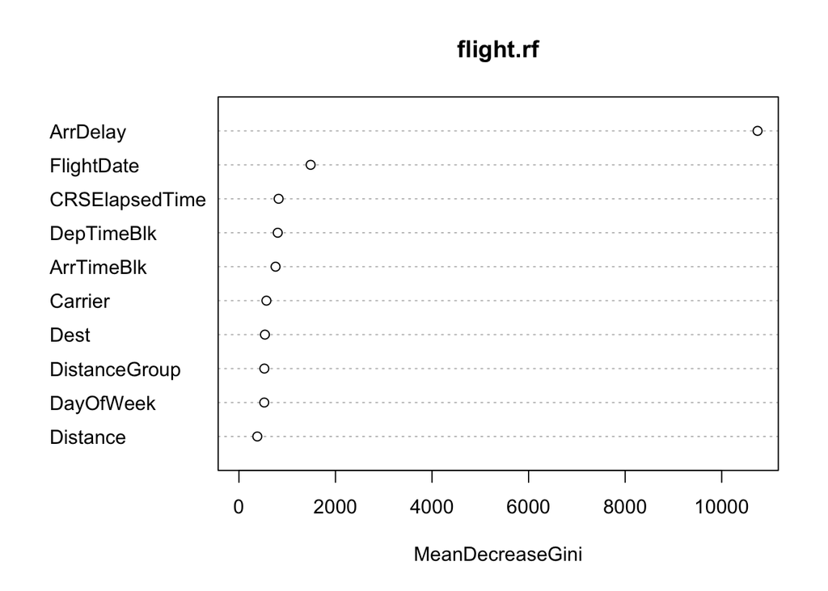

```r
#Split the data into 2 sets for Random Forest
set.seed(1)
n <- nrow(flight)
shuffled_df <- flight[sample(n), ]
train_indices <- 1:round(0.6 * n)
train.rf <- shuffled_df[train_indices, ]
test_indices <- (round(0.6 * n) + 1):n
test.rf <- shuffled_df[test_indices, ]


# Creating a random forest to test  classify
flight.rf =  randomForest(as.factor(DepDel15) ~ ., data = train.rf)
#Discernign a Decision Tree
varImpPlot(flight.rf)
```

```r
varImp(flight.rf)
```

```
##                   Overall
## FlightDate      1485.4574
## Carrier          569.4672
## DayOfWeek        524.4958
## Distance         380.4835
## ArrDelay       10743.0477
## DistanceGroup    526.6675
## CRSElapsedTime   822.2332
## ArrTimeBlk       759.1943
## DepTimeBlk       803.6644
## Dest             538.6101
```

```r
predict.rf = predict(flight.rf, newdata = test.rf,  type = "class" )
confusionMatrix(predict.rf, test.rf$DepDel15)
```

```
## Confusion Matrix and Statistics
##
##           Reference
## Prediction     0     1
##          0 29285  2777
##          1   629  4572
##
##                Accuracy : 0.9086
##                  95% CI : (0.9056, 0.9115)
##     No Information Rate : 0.8028
##     P-Value [Acc > NIR] : < 2.2e-16
##
##                   Kappa : 0.6756
##  Mcnemar's Test P-Value : < 2.2e-16
##
##             Sensitivity : 0.9790
##             Specificity : 0.6221
##          Pos Pred Value : 0.9134
##          Neg Pred Value : 0.8791
##              Prevalence : 0.8028
##          Detection Rate : 0.7859
##    Detection Prevalence : 0.8604
##       Balanced Accuracy : 0.8005
##
##        'Positive' Class : 0
##
```

```r
#Predicting on 20016 Data

flight.rf =  randomForest(DepDel15 ~ ., data = flight) # Training on the entire  2006 data
predict.rf = predict(flight.rf, newdata = flight2016,  type = "class" )
confusionMatrix(predict.rf, flight2016$DepDel15, positive = "1")
```

```
## Confusion Matrix and Statistics
##
##           Reference
## Prediction     0     1
##          0 26802  1744
##          1   385  3193
##
##                Accuracy : 0.9337
##                  95% CI : (0.931, 0.9364)
##     No Information Rate : 0.8463
##     P-Value [Acc > NIR] : < 2.2e-16
##
##                   Kappa : 0.7129
##  Mcnemar's Test P-Value : < 2.2e-16
##
##             Sensitivity : 0.6467
##             Specificity : 0.9858
##          Pos Pred Value : 0.8924
##          Neg Pred Value : 0.9389
##              Prevalence : 0.1537
##          Detection Rate : 0.0994
##    Detection Prevalence : 0.1114
##       Balanced Accuracy : 0.8163
##
##        'Positive' Class : 1
##
```

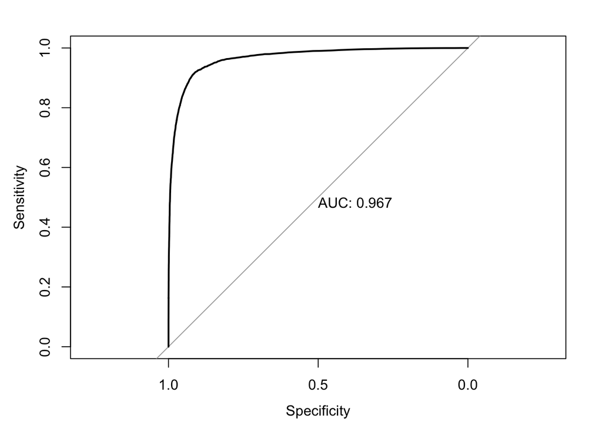

```r
#ROC Curve
prob.rf = predict(flight.rf, newdata = flight2016, type = "prob" )
prob.rf = data.frame(prob.rf)
roc.rf = roc(flight2016$DepDel15, prob.rf$X1)
plot(roc.rf, print.auc = TRUE)
```

```r
flights.dummy2016 = na.omit(flights.dummy2016)
flights.dummy = na.omit(flights.dummy)
#Decision Tree
flight.tree = tree(as.factor(DepDel15) ~ ., data = train)
predict.tree = predict(flight.tree, newdata  = test,  type = "class" )
table(predict.tree, test$DepDel15)
```

```
##
## predict.tree     0     1
##            0 29401  3129
##            1   575  4158
```

```r
mean(predict.tree == test$DepDel15)
```

```
## [1] 0.9005984
```

```r
#Predicting on the 2016 Data
flight.tree = tree(as.factor(DepDel15) ~ ., data = flights.dummy)
predict.tree = predict(flight.tree, newdata  = flights.dummy2016,  type = "class" )
table(predict.tree, flights.dummy2016$DepDel15)
```

```
##
## predict.tree     0     1
##            0 27021  2431
##            1   166  2506
```

```r
confusionMatrix(predict.tree, flights.dummy2016$DepDel15 , positive = "1")
```

```
## Confusion Matrix and Statistics
##
##           Reference
## Prediction     0     1
##          0 27021  2431
##          1   166  2506
##
##                Accuracy : 0.9192
##                  95% CI : (0.9161, 0.9221)
##     No Information Rate : 0.8463
##     P-Value [Acc > NIR] : < 2.2e-16
##
##                   Kappa : 0.6174
##  Mcnemar's Test P-Value : < 2.2e-16
##
##             Sensitivity : 0.50760
##             Specificity : 0.99389
##          Pos Pred Value : 0.93787
##          Neg Pred Value : 0.91746
##              Prevalence : 0.15369
##          Detection Rate : 0.07801
##    Detection Prevalence : 0.08318
##       Balanced Accuracy : 0.75074
##
##        'Positive' Class : 1
##
```

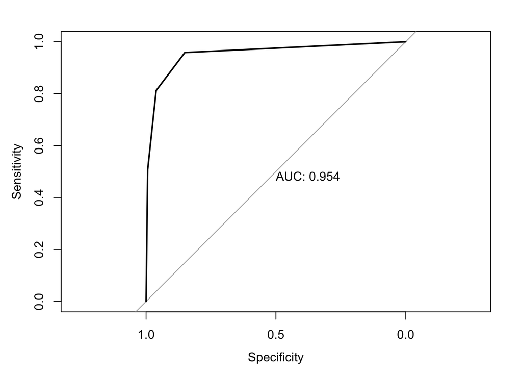

```r
#Take the Probability
prob.tree = predict(flight.tree, newdata  = flights.dummy2016,  class = "prob" )
prob.tree = data.frame(prob.tree)

#ROC Curve
roc.dt = roc(flights.dummy2016$DepDel15, prob.tree$X1)
plot(roc.dt, print.auc = TRUE)
```

Section 3 - Key Findings and Model Selection

- With the current data, Logistic model was able to correctly predict significant number of times when the flight was actually delayed. And, it was also able to classify correctly a good number of cases where, the flight was not delayed (High Specificity)

Q3 : Suppose you are asked to design an analytical component of a personalized flight delay warning system. Can the available data be used to build such a tool? What aspects of it may be useful? Demonstrate your ideas with examples of analysis of the data focusing on specific anticipated use cases. Discuss limitations of the data at hand and evaluate availability and potential utility of an alternative sources of relevant information.

[output not shown]

```r
WeatherDepDelay <- nrow(flight[(flight$WeatherDelay > 0) & (flight$DepDel15 == 1), ])
WeatherDepDelay
```

```
## [1] 0
```

```r
CarrierDepDelay <- nrow(flight[(flight$CarrierDelay > 0) & (flight$DepDel15 == 1), ])
CarrierDepDelay
```

```
## [1] 0
```

```r
NASDepDelay <- nrow(flight[(flight$NASDelay > 0) & (flight$DepDel15 == 1), ])
NASDepDelay
```

```
## [1] 0
```

```r
SecurityDepDelay <- nrow(flight[(flight$SecurityDelay > 0) & (flight$DepDel15 == 1), ])
SecurityDepDelay
```

```
## [1] 0
```

```r
LateAircraftDepDelay <- nrow(flight[(flight$LateAircraftDelay > 0) & (flight$DepDel15 == 1), ])
LateAircraftDepDelay
```

```
## [1] 0
```

Q4: What has changed at PIT airport since 2006 when it comes to flight delays?

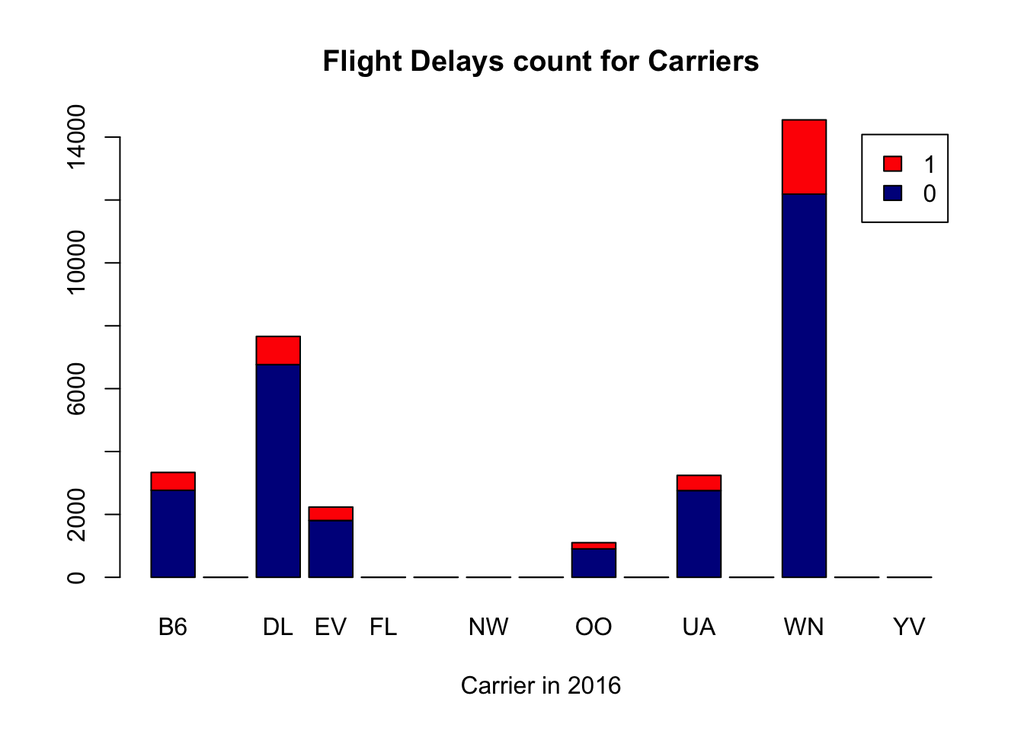

```r
count1 <- table(flight2016$DepDel15, flight2016$Carrier)
barplot(count1, main="Flight Delays count for Carriers",
 xlab="Carrier in 2016", col=c("darkblue","red"),
    legend = rownames(count1))
```

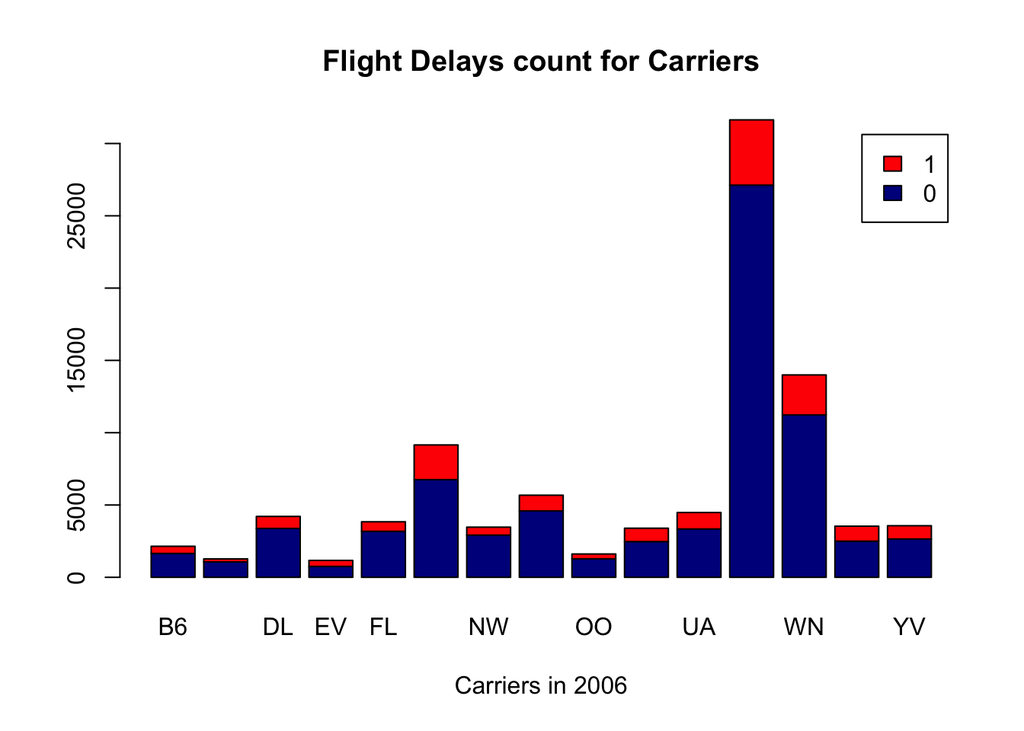

```r
count1 <- table(flight$DepDel15, flight$Carrier)
barplot(count1, main="Flight Delays count for Carriers",
  xlab="Carriers in 2006", col=c("darkblue","red"),
    legend = rownames(count1))
```